# lista4_EDA

### EPD080 - Introdução ao Python

### Lista de Exercícios 3 - EDA

#### Autor: Pedro Henrique Resende Marques

### Análise Exploratória de Dados de bandas de Heavy Metal

Nesta análise pretende-se observar características gerais das maiores bandas de heavy metal do mundo e possíveis correlações com os seus locais de origem. É necessário esclarecer que a base de dados utilizada não contém todas as bandas e pode estar desatualizada. Porém, ela é útil para fornecer informações interessantes através de um EDA.

```python
# SE VOCE NAO TEM O MODULO PLOTLY RODE O COMANDO BASH ABAIXO:
#!pip install plotly
import plotly.graph_objects as go
import numpy as np
import pandas as pd
import seaborn as sns
import matplotlib.patches as mpatches
import matplotlib.pyplot as plt
%matplotlib inline

mundo = pd.read_csv('world_population_1960_2015.csv', encoding='latin-1')
bandas = pd.read_csv('metal_bands_2017.csv', encoding='latin-1')
```

Abaixo, estão relacionados os 10 países com o maior número de bandas de Heavy Metal.

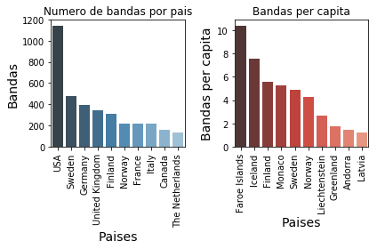

```python
bandas_pais = bandas['origin'].value_counts()
plt.subplot(1, 2, 1)
plt.title('Numero de bandas por pais')
plt.xticks(rotation=90)
sns.barplot(x=bandas_pais[:10].keys(), y=bandas_pais[:10].values, palette="Blues_d")
plt.ylabel("Bandas", fontsize=14)
plt.xlabel("Paises", fontsize=14)
num_bandas = [0 for i in range(len(mundo))]
for i, pais in mundo.iterrows():
    if pais['Country Name'] in bandas_pais:
        num_bandas[i] = bandas_pais[pais['Country Name']]
mundo['metal_pc'] = (pd.Series(num_bandas) / mundo['2015']) * 100000
mundo = mundo.sort_values(by = 'metal_pc', ascending=False)
plt.subplot(1, 2, 2)
plt.title('Bandas per capita')
plt.xticks(rotation=90)
sns.barplot(x=mundo[:10]['Country Name'], y=mundo[:10]['metal_pc'], palette="Reds_d")
plt.ylabel("Bandas per capita", fontsize=14)
plt.xlabel("Paises", fontsize=14)
plt.tight_layout()
#plt.show()
```

A seguir, encontra-se um mapa que mostra quais países tem mais bandas per capita no mundo. Uma nova maneira, mais intuitiva, de mostrar as informações do primeiro gráfico.

```python
df = pd.read_csv('plotly_countries_and_codes.csv')
df = df.sort_values(by='COUNTRY', ascending=True)
mundo = mundo.rename(columns={'Country Name':'COUNTRY'})
df = pd.merge(df, mundo, on='COUNTRY', how='left')
df = df.sort_values(by="metal_pc",ascending=False)
fig = go.Figure(data=go.Choropleth(
    locations = df['CODE'],
    z = df['metal_pc'],
    text = df['COUNTRY'],
    colorscale = 'Blues',
    autocolorscale=False,
    reversescale=True,
    marker_line_color='darkgray',
    marker_line_width=0.5,
    #colorbar_tickprefix = '$',
    colorbar_title = 'Bandas<br>per capita',
))
fig.show()
```

[interactive chart not shown]

Podemos notar que existe uma grande diferença quando se comparam o número de bandas por país com o número per capita de bandas por país. Nota-se, comparando os dois gráficos que os países escandinavos são os com maior concentração de bandas.

Abaixo, estão elencados os principais subgêneros de metal agrupados por popularidade e por estilos de cada banda.

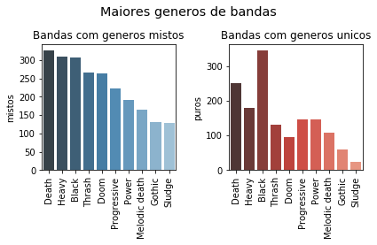

```python
#dicionarios com os estilos das bandas, se ha + de 1, entao eh misto
misto = {}
puro = {}
todos = {}
for tipo in bandas['style']:
    subs = tipo.split(',')
    for ind in subs:
            todos[ind] = todos.get(ind, 0) + 1
    if (len(subs) == 1):
        puro[subs[0]] = puro.get(subs[0], 0) + 1
    else:
        for ind in subs:
            misto[ind] = misto.get(ind, 0) + 1
tipos_df = pd.DataFrame()
tipos_df['mistos'] = pd.Series(misto)
tipos_df['puros'] = pd.Series(puro)
tipos_df['todos'] = pd.Series(todos)
tipos_df = tipos_df.sort_values(by='mistos', ascending=False)[:10]
fig = plt.figure()
st = fig.suptitle("Maiores generos de bandas", fontsize="x-large")
plt.subplot(1, 2, 1)
sns.barplot(x=tipos_df.index, y=tipos_df['mistos'], palette="Blues_d")
plt.title("Bandas com generos mistos")
plt.xticks(rotation=90)
plt.subplot(1, 2, 2)
sns.barplot(x=tipos_df.index, y=tipos_df['puros'], palette="Reds_d")
plt.title("Bandas com generos unicos")
plt.xticks(rotation=90)
plt.tight_layout()
st.set_y(0.95)
fig.subplots_adjust(top=0.80)
```

Observa-se que estilos extremos, como Black e Death Metal são os mais numerosos, com o Heavy Metal tradicional em seguida. Isso evidencia que o Metal passa por uma tendência que favorece estilos mais pesados. Abaixo, encontra-se a mesma informação comparada de forma diferente, para cada tipo principal, quantas bandas adotam estilos mistos e quantas adotam um estilo "puro".

[figure not shown]

```python
tipos_df[['puros', 'mistos']].plot(kind='bar', color=['blue', 'orange'])
plt.title('Generos de bandas mais populares')
misto_legenda = mpatches.Patch(color='blue', label='Puros')
puro_legenda = mpatches.Patch(color='orange', label='Mistos')
plt.legend(handles=[misto_legenda, puro_legenda])
```

A seguir, um gráfico apresenta a quantidade de bandas criadas por ano entre 1964 e 2016. Nota-se que há uma tendência de crescimento até o início dos anos 2000, quando começa uma forte queda na criação de novas bandas. O que pode significar que o gênero pode ficar estagnado num futuro próximo.

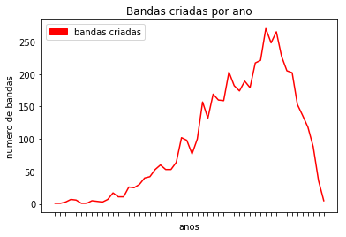

```python
criacoes = list(bandas['formed'].to_dict().values())
separacoes = list(bandas['split'].to_dict().values())
criacoes_ano = {i:criacoes.count(i) for i in criacoes if '-' not in i}
separacoes_ano = {i:separacoes.count(i) for i in separacoes if '-' not in i}
plt.title('Bandas criadas por ano')
ax = sns.lineplot(x=list(criacoes_ano.keys()), y = list(criacoes_ano.values()), color='red')
ax.set(xlabel='anos', ylabel='numero de bandas', xticklabels=[])
bds = mpatches.Patch(color='red',label="bandas criadas")
plt.legend(handles=[bds])
plt.show()
```

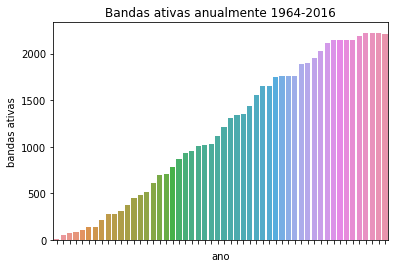

```python
bandas_ativas = {}
aux = 0
for k in criacoes_ano.keys():
    total = aux + criacoes_ano[k]
    if k in separacoes_ano:
        total -= separacoes_ano[k]
    bandas_ativas[k] = total
    aux = total
plt.title('Bandas ativas anualmente 1964-2016')
ax = sns.barplot(x=sorted(list(bandas_ativas.keys())), y = list(bandas_ativas.values()))
ax.set(xlabel='ano', ylabel='bandas ativas', xticklabels=[])
plt.show()
```

Assim, conclui-se esta análise exploratória de dados de bandas de Heavy Metal. As limitações do dataset impediram que certas perguntas mais complexas fossem feitas. Porém, informações interessantes deste gênero musical puderam ser obtidas e relacionadas de forma a entender a evolução do movimento musical ao longo dos últimos anos.